# Cytokines

```r
# loading packages
library(tidyverse)
library(skimr)
library(ggtext)
library(scales)
library(lme4)
library(lmerTest)
library(emmeans)
library(knitr)
library(ggpubr)
library(patchwork)
library(plotly)
library(gridExtra)
library(writexl)
library(ggrepel)
library(mixOmics)
library(Cairo)
```

## Data Input

All data inputs and outputs in this repo are relative to **FOLDER_PATH**. Please, save the provided data frames in RDS format in the `dataframes` folder.

```r
# Define directory paths based on R.environ
FOLDER_PATH <- Sys.getenv("BOX_PATH_RSVBacPublication")
dataframes_folder <- file.path(FOLDER_PATH, "dataframes")

# Create subfolder for output files
outputs_folder <- file.path(FOLDER_PATH, "outputs/Cytokines")
if (!file.exists(outputs_folder)) {
  dir.create(outputs_folder, recursive = TRUE)
}
```

```r
# Read the provided RDS file
dataframeID <- "RSVbac"
Cytokines_data <- readRDS(file.path(dataframes_folder, paste0(dataframeID, "_Cytokine_values.rds")))
```

## RSVbac 4 DPVI

```r
# Filter data for 4 DPVI timepoint
Cytokines_data_t4 <- Cytokines_data %>%
  filter(time_inf == "4")

# Create subfolder for output files
outputs_folder <- file.path(FOLDER_PATH, "outputs/Cytokines/4_DPVI")
if (!file.exists(outputs_folder)) {
  dir.create(outputs_folder, recursive = TRUE)
}

# Colors
Bac.colors <- c("#a89de0", "#f54590", "#2e67f2")
Bac.Vir_colors <- c("#CC9564", "#a89de0", "#f54590", "#2e67f2", "#856141","#6855c9","#9f2d5e", "#1e439d")
Bac.Vir_fill <- c("white", "white", "white", "white", "#856141","#6855c9","#9f2d5e", "#1e439d")
```

### LOD and Heatmap of log2FC

This section performs quality control by calculating log2 fold changes (log2FC) relative to control samples (NB.NV), evaluating the proportion of samples above the detection limit for each cytokine-location combination, and assessing the dynamic range of responses. Cytokine-location groups with less than 25% detection across all samples are flagged as rejected and excluded from subsequent statistical analyses. Results are visualized through bar plots showing detection rates and dynamic ranges, a scatter plot examining the relationship between detection and range, and a heatmap displaying average log2FC values for each cytokine-location group. Samples highlighted in grey in the heatmap correspond to rejected cytokine-location groups (less than 25% of samples above detection limit).

```r
log2FC_analysis <- function(df) {

  # Step 1: Calculate log2FC relative to defined controls
  df_log2FC <- df %>%
    group_by(date, Cyto, Category, location, line, time_inf) %>%
    reframe(
      bacteria = bacteria[sample_type == "experimental"],
      virus = virus[sample_type == "experimental"],
      Bac.Vir = Bac.Vir[sample_type == "experimental"],
      Bac.Vir_label = Bac.Vir_label[sample_type == "experimental"],
      log2FC = log2(concentration[sample_type == "experimental"] / concentration[sample_type == "control"]),
      log2ctl = log2(concentration[sample_type == "control"]),
      below_LD = below_LD[sample_type == "experimental"],
      above_LD = above_LD[sample_type == "experimental"]
    )

  # Step 2: Calculate proportion of samples above detection limit
  LD <- df %>%
    group_by(Cyto, location) %>%
    summarise(detected_all = 1 - mean(below_LD), .groups = 'drop') %>%
    mutate(group_label = paste(Cyto, location, sep = "_")) %>%
    relocate(group_label, .after = location)

  # Step 3: Plot detection limit proportions
  plot_select_function <- function(data, x_var, title) {
    ggplot(data = data, aes(x = reorder(group_label, {{x_var}}), y = {{x_var}}, fill = location)) +
      geom_bar(stat = "identity", position = position_dodge()) +
      scale_y_continuous(expand = c(0, 0)) +
      scale_fill_manual(values = c("coral", "steelblue1")) +
      coord_flip() +
      labs(title = title, x = "", y = "") +
      theme_bw() +
      theme(panel.grid = element_blank(),
            text = element_text(size = 10))
  }

  p_LD <- plot_select_function(LD, detected_all, "Proportion of samples above detection limit")

  # Step 4: Calculate range of log2FC values relative to the controls
  range_log2FC <- df_log2FC %>%
    group_by(Cyto, location) %>%
    mutate(min = ifelse(is.na(log2FC), 0, min(log2FC, na.rm = TRUE))) %>%
    mutate(max = max(log2FC, na.rm = TRUE)) %>%
    mutate(range = max - min) %>%
    summarise(range = mean(range, na.rm = TRUE), .groups = 'drop')

  # Step 5: Merge detection and range data
  select_summary <- left_join(LD, range_log2FC, by = join_by(Cyto, location)) %>%
    mutate(group_label = paste(Cyto, location, sep = "_"))

  # Step 6: Plot range
  p_range <- plot_select_function(select_summary, range, "Range of log2FC values relative to the controls")

  # Step 7: Define rejected groups
  select_summary <- select_summary %>%
    mutate(group_rejected = as.factor(ifelse(detected_all < 0.25, TRUE, FALSE)))

  # Step 8: Plot correlation
  p_correlation_FC <- ggplot(select_summary, aes(x = range, y = detected_all, color = Cyto, shape = location)) +
    geom_point(aes(size = group_rejected)) +
    scale_size_manual(values = c(4, 2)) +
    theme_bw() +
    theme(panel.grid = element_blank(),
          text = element_text(size = 10)) +
    labs(x = "log2FC range",
         y = "Proportion of samples above detection limit (pg/mL values)")

  # Step 9: Merge rejection info
  df_log2FC <- left_join(df_log2FC, select_summary, by = join_by(Cyto, location))

  # Step 10: Average log2FCs
  Avg_df_log2FC <- df_log2FC %>%
    group_by(Cyto, Category, location, virus, bacteria, Bac.Vir, Bac.Vir_label, group_rejected) %>%
    summarize(avg_log2FC = mean(log2FC, na.rm = TRUE), .groups = 'drop') %>%
    mutate(value = ifelse(group_rejected == TRUE, NA, avg_log2FC))

  # Step 11: Create heatmap
  plot_heatmap <- function(data) {
    ggplot(data, aes(x = Cyto, y = Bac.Vir_label, fill = value)) +
      geom_tile(color = "black") +
      facet_grid(location ~ Category , space = "free", scales = "free") +
      scale_fill_gradient2(low = "#009ad1", high = "#AD1457",
                           mid = "#fefbea", na.value = "grey",
                           name = expression("Log" [2]*"FC")) +
      labs(x = "", y = "") +
      scale_y_discrete(expand = c(0,0), limits = rev) +
      scale_x_discrete(expand = c(0,0), limits = rev) +
      theme_bw() +
      theme(panel.grid.major = element_blank(),
            panel.grid.minor = element_blank(),
            strip.background = element_rect(colour = "black", fill = NA),
            strip.text.y = element_text(angle = -90, hjust = 0.5, size = 14, face = "bold"),
            strip.text.x = element_text(size = 12),
            axis.text.y = element_markdown(size = 14),
            axis.text.x = element_text(size = 12, angle = 67, hjust = 1, colour = "black"),
            legend.title = element_text(size = 14),
            legend.text = element_text(size = 14),
            panel.spacing = unit(4, 'pt')
      )
  }

  heatmap <- plot_heatmap(Avg_df_log2FC)

  # Return results
  return(list(
    df_log2FC = df_log2FC,
    Avg_df_log2FC = Avg_df_log2FC,
    select_summary = select_summary,
    p_LD = p_LD,
    p_range = p_range,
    p_correlation_FC = p_correlation_FC,
    heatmap = heatmap
  ))
}
```

```r
# NB.NV considered as control samples for the log2FC calculation
LD_data <- Cytokines_data_t4 %>%
  mutate(sample_type = if_else(bacteria == "NB" & virus == "NV", "control", "experimental"))
log2FC_results <- log2FC_analysis(LD_data)
```

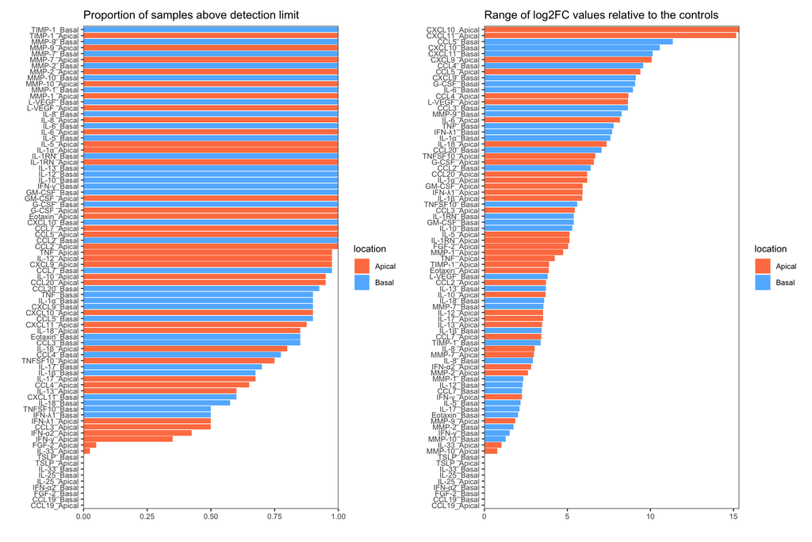

```r
log2FC_results$p_LD + log2FC_results$p_range
```

```r
ggplotly(log2FC_results$p_correlation_FC)
```

[interactive chart not shown]

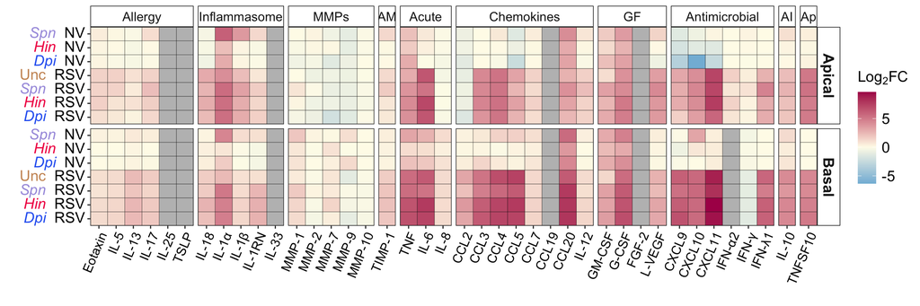

```r
log2FC_results$heatmap
```

```r
# Save log2FC_results
saveRDS(log2FC_results, file = file.path(outputs_folder, paste0(dataframeID, "_log2FC_results_t4.rds")))

# Merging the rejection info with the original data
Cytokines_data_t4 <- left_join(Cytokines_data_t4, log2FC_results$select_summary, by = join_by(Cyto, location))
saveRDS(Cytokines_data_t4, file = file.path(dataframes_folder, paste0(dataframeID, "_Cytokine_values_t4.rds")))

# Filtering out rejected groupings
Cytokines_data_t4 <- Cytokines_data_t4 %>%
  filter(group_rejected == FALSE)
```

### mixOmics Analysis

#### Data Preparation

Data is reshaped into a matrix format suitable for mixOmics analysis, with samples as rows and cytokines as columns. Each sample is uniquely identified by the combination of bacteria, virus, line, and date. Metadata (including experimental conditions and grouping variables) is separated from the concentration matrix. Apical and basal datasets are prepared separately for subsequent PCA and PLS-DA analyses.

```r
# Function to reshape data for mixOmics
prepare_data <- function(data) {
  # Create wide format: rows = samples, columns = cytokines
  wide <- data %>%
    # Create unique sample identifier for each replicate
    mutate(sample_id = paste(bacteria, virus, line, date, sep = "_")) %>%
    dplyr::select(sample_id, bacteria, virus, line, date, Cyto, concentration, Bac.Vir, Bac.Vir_label) %>%
    pivot_wider(
      id_cols = c(sample_id, bacteria, virus, line, date, Bac.Vir, Bac.Vir_label),
      names_from = Cyto,
      values_from = concentration
    )

  # Separate metadata and data matrix
  metadata <- wide %>%
    dplyr::select(sample_id, bacteria, virus, line, date, Bac.Vir, Bac.Vir_label)

  matrix_data <- wide %>%
    dplyr::select(-sample_id, -bacteria, -virus, -line, -date, -Bac.Vir, -Bac.Vir_label) %>%
    as.matrix()

  # Convert Bac.Vir to factor if not already
  metadata$Bac.Vir <- factor(metadata$Bac.Vir)
  metadata$Bac.Vir_label <- factor(metadata$Bac.Vir_label)

  return(list(matrix_data = matrix_data, metadata = metadata))
}

# Prepare apical and basal data
data_A <- Cytokines_data_t4 %>% filter(location == "Apical")
data_B <- Cytokines_data_t4 %>% filter(location == "Basal")
mixOmics_data_A <- prepare_data(data_A)
mixOmics_data_B <- prepare_data(data_B)
```

#### PCA Analysis

Principal component analysis is performed to assess data structure and batch effects with a multilevel design that accounts for batch date effects. Variance explained by each component is visualized, along with PCA plots for the first 2 components, with points colored by treatment condition (bacteria * virus combination), filled by virus presence/absence, and shaped by cell line. Data are mean-centered and scaled to unit variance prior to analysis.

```r
# Function 1: Explore variance explained by PCA components
explore_pca <- function(mixomics_data, location_name, multilevel_column = NULL, max_ncomp = 10) {

  # Extract data
  matrix_data <- mixomics_data$matrix_data
  metadata <- mixomics_data$metadata

  # Handle multilevel input
  multilevel_data <- if (!is.null(multilevel_column)) metadata[[multilevel_column]] else NULL

  # Run PCA
  pca_result <- pca(matrix_data,
                    ncomp = max_ncomp,
                    multilevel = multilevel_data,
                    center = TRUE,
                    scale = TRUE)

  # Explained variance
  explained_var <- round(pca_result$prop_expl_var$X * 100, 2)
  df_explained <- data.frame(Component = 1:max_ncomp, Variance = explained_var)

  # Create ggplot
  plot <- ggplot(df_explained, aes(x = Component, y = Variance)) +
    geom_bar(stat = "identity", fill = "springgreen4") +
    geom_text(aes(label = paste0(Variance, "%")),
              vjust = -0.5,
              size = 3) +
    scale_x_continuous(breaks = seq(min(df_explained$Component), max(df_explained$Component), by = 1)) +
    scale_y_continuous(expand = c(0, 0), limits = c(0, 70)) +
    theme_bw() +
    theme(
      plot.margin = margin(t = 10, r = 10, b = 10, l = 10),
      panel.grid.major = element_blank(),
      panel.grid.minor = element_blank(),
      axis.title = element_text(size = 12),
      axis.text = element_text(size = 10, color = "black")
    ) +
    ggtitle(paste0("PCA Variance per Component (", location_name, ")")) +
    ylab("Variance (%)")

  return(plot)
}

# Function 2: Run and plot PCA with chosen parameters
run_and_plot_pca <- function(mixomics_data, location_name, multilevel_column = NULL,
                             group_var, pch_var = "line", colors = NULL, fills = NULL,
                             ncomp = 2, comp_x = 1, comp_y = 2) {

  # Extract data
  matrix_data <- mixomics_data$matrix_data
  metadata <- mixomics_data$metadata

  # Handle multilevel input
  multilevel_data <- if (!is.null(multilevel_column)) metadata[[multilevel_column]] else NULL

  # Get the grouping variable
  group_variable <- metadata[[group_var]]
  pch_variable <- metadata[[pch_var]]

  # Run PCA
  pca_result <- pca(matrix_data,
                    ncomp = ncomp,
                    multilevel = multilevel_data,
                    center = TRUE,
                    scale = TRUE)

  # Extract scores for ggplot
  scores <- as.data.frame(pca_result$variates$X)

  # Assign original pch variable
  scores[[pch_var]] <- pch_variable

  # Assign original group variable with dots
  scores[[group_var]] <- group_variable

  # Now relabel the group_var column (preserving factor levels if needed)
  scores[[group_var]] <- factor(scores[[group_var]],
                                levels = levels(factor(scores[[group_var]])),
                                labels = gsub("\\.", " ", levels(factor(scores[[group_var]]))))

  # Get variance explained for axis labels
  var_exp <- round(pca_result$prop_expl_var$X * 100, 2)

  # Create ggplot with fill for virus and color for Bac.Vir
  plot <- ggplot(scores, aes(x = .data[[paste0("PC", comp_x)]],
                             y = .data[[paste0("PC", comp_y)]])) +
    geom_point(aes(fill = .data[[group_var]], color = .data[[group_var]], shape = .data[[pch_var]]),
               size = 3, stroke = 1.5) +
    scale_fill_manual(values = fills, name = "Condition") +
    scale_color_manual(values = colors, name = "Condition") +
    scale_shape_manual(values = c(21, 24), name = "Line") +
    scale_x_continuous(labels = function(x) sprintf("%.1f", x)) +
    scale_y_continuous(labels = function(x) sprintf("%.1f", x)) +
    theme_bw() +
    theme(
      plot.margin = margin(t = 10, r = 10, b = 10, l = 10),
      panel.grid.major = element_blank(),
      panel.grid.minor = element_blank(),
      axis.title = element_text(size = 12),
      axis.text = element_text(size = 10, color = "black"),
      legend.text = element_markdown(size = 10),
      legend.position = "right"
    ) +
    labs(
      title = paste0("PCA (", location_name, ")"),
      x = paste0("PC", comp_x, " (", var_exp[comp_x], "%)"),
      y = paste0("PC", comp_y, " (", var_exp[comp_y], "%)")
    ) +
    guides(
      fill = guide_legend(override.aes = list(color = colors, shape = 22))
    )

  return(plot)
}
```

```r
pca_explore_A_multilevel <- explore_pca(mixOmics_data_A, "Apical", multilevel_column = "date")
pca_explore_B_multilevel <- explore_pca(mixOmics_data_B, "Basal", multilevel_column = "date")

pca_A_BacVir_multilevel <- run_and_plot_pca(mixOmics_data_A, "Apical", multilevel_column = "date", group_var = "Bac.Vir_label", colors = Bac.Vir_colors, fills = Bac.Vir_fill)
pca_B_BacVir_multilevel <- run_and_plot_pca(mixOmics_data_B, "Basal", multilevel_column = "date", group_var = "Bac.Vir_label", colors = Bac.Vir_colors, fills = Bac.Vir_fill)

# Save PCA results
saveRDS(pca_explore_A_multilevel, file.path(outputs_folder, paste0(dataframeID, "_PCA_explore_A_multilevel_t4.rds")))
saveRDS(pca_explore_B_multilevel, file.path(outputs_folder, paste0(dataframeID, "_PCA_explore_B_multilevel_t4.rds")))
saveRDS(pca_A_BacVir_multilevel, file.path(outputs_folder, paste0(dataframeID, "_PCA_A_BacVir_multilevel_t4.rds")))
saveRDS(pca_B_BacVir_multilevel, file.path(outputs_folder, paste0(dataframeID, "_PCA_B_BacVir_multilevel_t4.rds")))
```

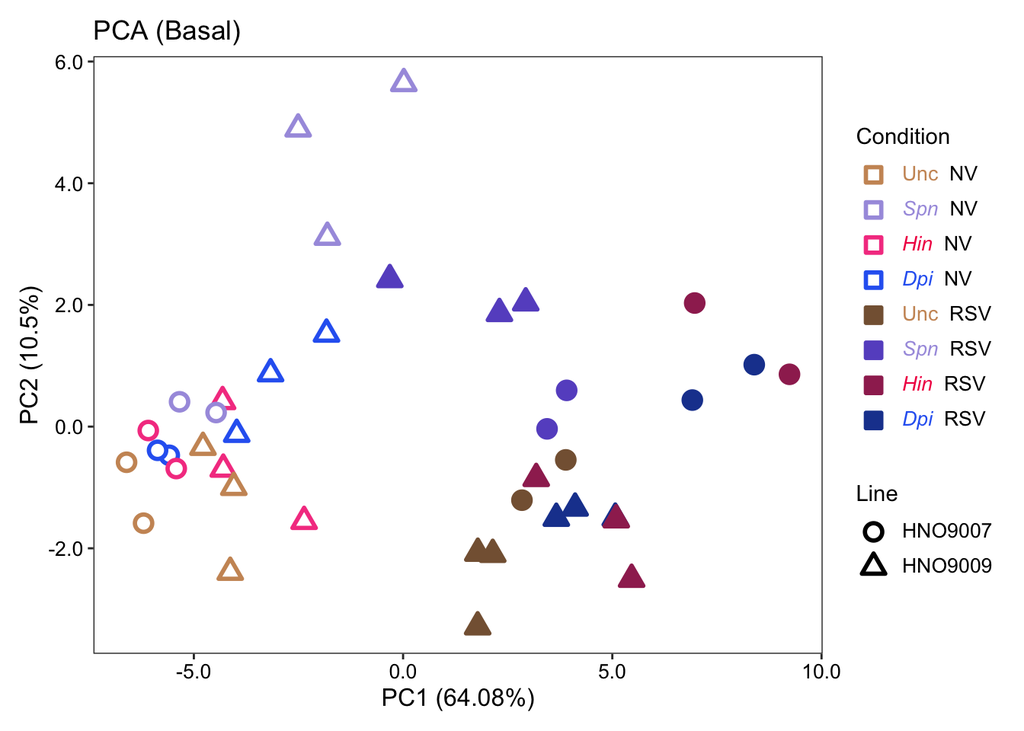

```r
pca_B_BacVir_multilevel
```

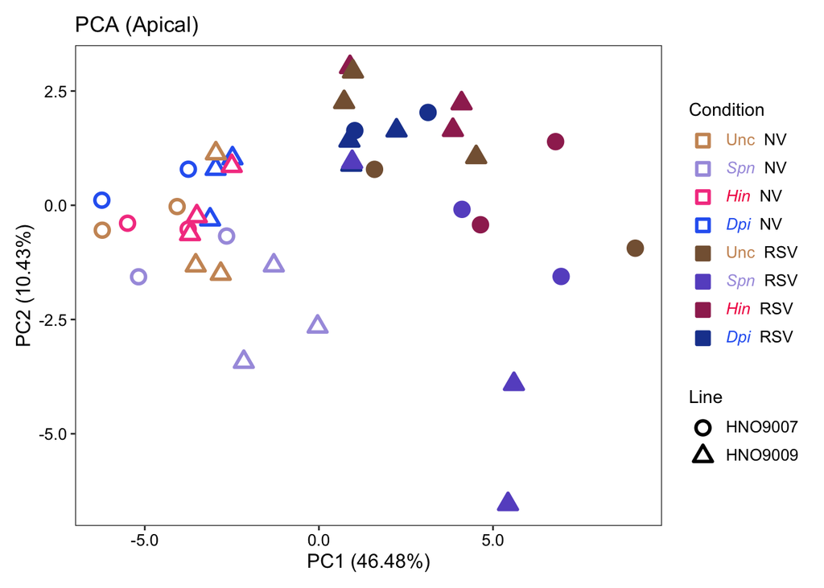

```r
pca_A_BacVir_multilevel
```

#### PLS-DA Analysis

Partial least squares discriminant analysis (PLS-DA) is performed to assess the separability of treatment groups based on cytokine profiles. Model performance is evaluated using 3-fold cross-validation repeated 50 times, with balanced error rate (BER) calculated using centroids distance classification. The optimal number of components is selected based on the minimum BER value across 3-fold cross-validation repeated 50 times. This cross-validation approach helps prevent overfitting while maximizing classification accuracy. Treatment condition (bacteria * virus combination) serves as the grouping variable, with a multilevel design accounting for repeated measures across experimental dates. Score plots for multiple component pairs are generated (components 1 vs 2, 1 vs 3, and 2 vs 3), with points colored by treatment condition, filled by virus presence/absence, and shaped by cell line. Ellipses represent 95% confidence intervals around group centroids. Data are mean-centered and scaled to unit variance prior to analysis.

```r
# Function 1: Explore PLS-DA - tune to find optimal components
explore_plsda <- function(mixomics_data, location_name, multilevel_column = NULL, max_ncomp = 10, group_var) {

  # Extract data
  matrix_data <- mixomics_data$matrix_data
  metadata <- mixomics_data$metadata

  # Get the grouping variable
  variable <- metadata[[group_var]]

  # Handle multilevel input
  multilevel_data <- if (!is.null(multilevel_column)) metadata[[multilevel_column]] else NULL

  # Initial PLS-DA
  plsda_result <- plsda(matrix_data,
                        variable,
                        multilevel = multilevel_data,
                        ncomp = max_ncomp,
                        scale = TRUE)

  # Cross-validation with M-fold
  perf_plsda <- perf(plsda_result,
                     validation = "Mfold",
                     dist = "centroids.dist",
                     folds = 3,
                     nrepeat = 50)

  # Optimal number of components
  optimal_ncomp <- perf_plsda$choice.ncomp["BER", "centroids.dist"]

  # Extract BER values for centroids.dist
  ber_data <- perf_plsda$error.rate$BER[, "centroids.dist"]

  # Create data frame for plotting
  plot_data <- data.frame(
    ncomp = 1:length(ber_data),
    BER = ber_data
  )

  # Create ggplot
  perf_plot <- ggplot(plot_data, aes(x = ncomp, y = BER)) +
    geom_line(color = "springgreen4", linewidth = 1) +
    geom_point(color = "springgreen4", size = 3, shape = 18) +
    geom_point(data = plot_data[optimal_ncomp, ],
               aes(x = ncomp, y = BER),
               color = "springgreen4", fill = "springgreen", size = 4, shape = 23) +
    labs(
      title = paste0("PLS-DA Performance (", location_name, ")"),
      x = "Number of Components",
      y = "Classification Error Rate"
    ) +
    theme_bw() +
    theme(
      plot.margin = margin(t = 10, r = 10, b = 10, l = 10),
      panel.grid.major = element_blank(),
      panel.grid.minor = element_blank(),
      axis.title = element_text(size = 12),
      axis.text = element_text(size = 10, color = "black")
    ) +
    scale_x_continuous(breaks = 1:max_ncomp)

  return(list(
    optimal_ncomp = optimal_ncomp,
    perf_plot = perf_plot
  ))
}

# Function 2: Run and plot PLS-DA with chosen parameters
run_and_plot_plsda <- function(mixomics_data, location_name, multilevel_column = NULL,
                               group_var, colors = NULL, fills = NULL,
                               ncomp = 2, comp_x = 1, comp_y = 2) {

  # Ensure at least 2 components for plotting
  ncomp <- max(2, ncomp)

  # Extract data
  matrix_data <- mixomics_data$matrix_data
  metadata <- mixomics_data$metadata

  # Handle multilevel input
  multilevel_data <- if (!is.null(multilevel_column)) metadata[[multilevel_column]] else NULL

  # Get the grouping variable
  variable <- metadata[[group_var]]

  # Run PLS-DA
  plsda_result <- plsda(matrix_data,
                        variable,
                        multilevel = multilevel_data,
                        ncomp = ncomp,
                        scale = TRUE)

  # Extract variates (component scores)
  variates <- plsda_result$variates$X

  # Create data frame for plotting
  plot_data <- data.frame(
    comp1 = variates[, comp_x],
    comp2 = variates[, comp_y],
    group = variable,
    line = metadata$line,
    virus = metadata$virus
  )

  # Get explained variance
  explained_var <- plsda_result$prop_expl_var$X
  x_label <- paste0("Component ", comp_x, " (",
                    round(explained_var[comp_x] * 100, 2), "%)")
  y_label <- paste0("Component ", comp_y, " (",
                    round(explained_var[comp_y] * 100, 2), "%)")

  # Create ggplot
  plot <- ggplot(plot_data, aes(x = comp1, y = comp2)) +
    geom_point(aes(fill = group, color = group, shape = line),
               size = 2, stroke = 1) +
    stat_ellipse(aes(color = group), type = "norm", level = 0.95, linewidth = 1, show.legend = F) +
    scale_fill_manual(values = fills, name = "Condition") +
    scale_color_manual(values = colors, name = "Condition") +
    scale_shape_manual(values = c(21, 24), name = "Line") +
    theme_bw() +
    theme(
      plot.margin = margin(t = 10, r = 10, b = 10, l = 10),
      panel.grid.major = element_blank(),
      panel.grid.minor = element_blank(),
      axis.title = element_text(size = 12),
      axis.text = element_text(size = 10, color = "black"),
      legend.position = "right"
    ) +
    labs(
      title = paste0("PLS-DA (", location_name, ")"),
      x = x_label,
      y = y_label
    ) +
    guides(
      fill = guide_legend(override.aes = list(color = colors, shape = 22))
    )

  # Return results
  return(plot)
}
```

```r
plsda_explore_A_multilevel <- explore_plsda(mixOmics_data_A, "Apical", multilevel_column = "date", group_var = "Bac.Vir")
plsda_explore_B_multilevel <- explore_plsda(mixOmics_data_B, "Basal", multilevel_column = "date", group_var = "Bac.Vir")

plsda_A_results_multilevel_1vs2 <- run_and_plot_plsda(mixOmics_data_A, "Apical", multilevel_column = "date", group_var = "Bac.Vir", colors = Bac.Vir_colors, fills = Bac.Vir_fill,
                                                 ncomp = plsda_explore_A_multilevel$optimal_ncomp, comp_x = 1, comp_y = 2)
plsda_A_results_multilevel_1vs3 <- run_and_plot_plsda(mixOmics_data_A, "Apical", multilevel_column = "date", group_var = "Bac.Vir", colors = Bac.Vir_colors, fills = Bac.Vir_fill,
                                                 ncomp = plsda_explore_A_multilevel$optimal_ncomp, comp_x = 1, comp_y = 3)
plsda_A_results_multilevel_2vs3 <- run_and_plot_plsda(mixOmics_data_A, "Apical", multilevel_column = "date", group_var = "Bac.Vir", colors = Bac.Vir_colors, fills = Bac.Vir_fill,
                                                 ncomp = plsda_explore_A_multilevel$optimal_ncomp, comp_x = 2, comp_y = 3)
plsda_B_results_multilevel_1vs2 <- run_and_plot_plsda(mixOmics_data_B, "Basal", multilevel_column = "date", group_var = "Bac.Vir", colors = Bac.Vir_colors, fills = Bac.Vir_fill,
                                                 ncomp = plsda_explore_B_multilevel$optimal_ncomp, comp_x = 1, comp_y = 2)
plsda_B_results_multilevel_1vs3 <- run_and_plot_plsda(mixOmics_data_B, "Basal", multilevel_column = "date", group_var = "Bac.Vir", colors = Bac.Vir_colors, fills = Bac.Vir_fill,
                                                 ncomp = plsda_explore_B_multilevel$optimal_ncomp, comp_x = 1, comp_y = 3)
plsda_B_results_multilevel_2vs3 <- run_and_plot_plsda(mixOmics_data_B, "Basal", multilevel_column = "date", group_var = "Bac.Vir", colors = Bac.Vir_colors, fills = Bac.Vir_fill,
                                                 ncomp = plsda_explore_B_multilevel$optimal_ncomp, comp_x = 2, comp_y = 3)

# Save PLS-DA results
saveRDS(plsda_explore_A_multilevel, file.path(outputs_folder, paste0(dataframeID, "_PLSDA_explore_A_multilevel_t4.rds")))
saveRDS(plsda_explore_B_multilevel, file.path(outputs_folder, paste0(dataframeID, "_PLSDA_explore_B_multilevel_t4.rds")))
saveRDS(plsda_A_results_multilevel_1vs2, file.path(outputs_folder, paste0(dataframeID, "_PLSDA_A_multilevel_1vs2_t4.rds")))
saveRDS(plsda_A_results_multilevel_1vs3, file.path(outputs_folder, paste0(dataframeID, "_PLSDA_A_multilevel_1vs3_t4.rds")))
saveRDS(plsda_A_results_multilevel_2vs3, file.path(outputs_folder, paste0(dataframeID, "_PLSDA_A_multilevel_2vs3_t4.rds")))
saveRDS(plsda_B_results_multilevel_1vs2, file.path(outputs_folder, paste0(dataframeID, "_PLSDA_B_multilevel_1vs2_t4.rds")))
saveRDS(plsda_B_results_multilevel_1vs3, file.path(outputs_folder, paste0(dataframeID, "_PLSDA_B_multilevel_1vs3_t4.rds")))
saveRDS(plsda_B_results_multilevel_2vs3, file.path(outputs_folder, paste0(dataframeID, "_PLSDA_B_multilevel_2vs3_t4.rds")))
```

### Stats and Individual Plots (pg/mL)

#### Handle missing values

This section summarizes the missing values in the dataset by bacteria-virus and cell line groups. It then filters out any rows with missing concentration values to prepare for statistical analysis.

```r
# Summary of missing values
Summary <- Cytokines_data_t4 %>%
  group_by(location, bacteria, virus, line) %>%
  summarise(
    missing = sum(is.na(concentration)),
    total = n()
  ) %>%
  mutate(percent_missing = round(missing / total * 100, 2))
kable(Summary)
```

| location | bacteria | virus | line | missing | total | percent_missing |
| --- | --- | --- | --- | --- | --- | --- |
| Apical | NB | NV | HNO9007 | 0 | 70 | 0.00 |
| Apical | NB | NV | HNO9009 | 0 | 105 | 0.00 |
| Apical | NB | RSV | HNO9007 | 0 | 70 | 0.00 |
| Apical | NB | RSV | HNO9009 | 0 | 105 | 0.00 |
| Apical | Spn | NV | HNO9007 | 0 | 70 | 0.00 |
| Apical | Spn | NV | HNO9009 | 1 | 105 | 0.95 |
| Apical | Spn | RSV | HNO9007 | 0 | 70 | 0.00 |
| Apical | Spn | RSV | HNO9009 | 0 | 105 | 0.00 |
| Apical | Hin | NV | HNO9007 | 0 | 70 | 0.00 |
| Apical | Hin | NV | HNO9009 | 0 | 105 | 0.00 |
| Apical | Hin | RSV | HNO9007 | 1 | 70 | 1.43 |
| Apical | Hin | RSV | HNO9009 | 0 | 105 | 0.00 |
| Apical | Dpi | NV | HNO9007 | 0 | 70 | 0.00 |
| Apical | Dpi | NV | HNO9009 | 0 | 105 | 0.00 |
| Apical | Dpi | RSV | HNO9007 | 1 | 70 | 1.43 |
| Apical | Dpi | RSV | HNO9009 | 0 | 105 | 0.00 |
| Basal | NB | NV | HNO9007 | 0 | 68 | 0.00 |
| Basal | NB | NV | HNO9009 | 0 | 102 | 0.00 |
| Basal | NB | RSV | HNO9007 | 0 | 68 | 0.00 |
| Basal | NB | RSV | HNO9009 | 0 | 102 | 0.00 |
| Basal | Spn | NV | HNO9007 | 0 | 68 | 0.00 |
| Basal | Spn | NV | HNO9009 | 0 | 102 | 0.00 |
| Basal | Spn | RSV | HNO9007 | 0 | 68 | 0.00 |
| Basal | Spn | RSV | HNO9009 | 0 | 102 | 0.00 |
| Basal | Hin | NV | HNO9007 | 0 | 68 | 0.00 |
| Basal | Hin | NV | HNO9009 | 0 | 102 | 0.00 |
| Basal | Hin | RSV | HNO9007 | 0 | 68 | 0.00 |
| Basal | Hin | RSV | HNO9009 | 0 | 102 | 0.00 |
| Basal | Dpi | NV | HNO9007 | 0 | 68 | 0.00 |
| Basal | Dpi | NV | HNO9009 | 0 | 102 | 0.00 |
| Basal | Dpi | RSV | HNO9007 | 0 | 68 | 0.00 |
| Basal | Dpi | RSV | HNO9009 | 0 | 102 | 0.00 |

```r
# Filter NA in concentration
Stats_values <- Cytokines_data_t4 %>%
  filter(!is.na(concentration)) %>%
  arrange(desc(range))
```

#### Statistical Analysis

This section performs univariate statistical analysis for each cytokine-location group separately using linear mixed-effects models. For each group, cytokine concentrations (log-transformed) are modeled as a function of bacteria treatment, virus treatment, and their interaction, with random effects for cell line and the cell line * date interaction to account for the nested repeated measures design. If the model is singular (typically due to zero variance for the line:date random effect), it is refitted with only date as a random effect. Model predictions and 95% confidence intervals are back-transformed to the original scale (pg/mL) for visualization.

Pairwise contrasts are computed for:

- Simple effects of bacteria (comparing bacteria treatments within each virus level)
- Simple effects of virus (comparing virus treatments within each bacteria level)
- Interaction effects (testing whether the virus effect differs between bacteria treatments, e.g., does RSV + Bacteria differ from RSV + No Bacteria by more than RSV alone differs from No Infection?)

```r
stats_function <- function(values_data, each_group) {

  # Subset the data
  data_subset <- values_data %>%
    filter(group_label == each_group)

  # Set NB as reference level for bacteria
  data_subset$bacteria <- relevel(factor(data_subset$bacteria), ref = "NB")

  # First run linear mixed-effects model with random effects
  model <- lmer(log(concentration) ~ bacteria * virus
                + (1|line) + (1|line:date),
                data = data_subset)

  # Extract random effects data and convert to dataframe
  singular = isSingular(model)
  random_effects_df <- as.data.frame(VarCorr(model)) %>%
    mutate(proportion = round(100 * (vcov / sum(vcov)), 2)) %>%
    mutate(singular = singular) %>%
    mutate(group_label = each_group)

  # If model is singular, rerun linear mixed-effects model with only date as random effect
  if (singular) {
    model <- lmer(log(concentration) ~ bacteria * virus
                  + (1|date),
                  data = data_subset)
  }

  # Run ANOVA and extract pvalues
  anova <- anova(model)
  bacteria_pvalue <- anova$`Pr(>F)`[1]
  virus_pvalue <- anova$`Pr(>F)`[2]
  interact_pvalue <- anova$`Pr(>F)`[3]

  # Extract fixed effects coefficients and convert to dataframe
  fixed_effects_df <- as.data.frame(summary(model)$coefficients) %>%
    rownames_to_column(var = "term") %>%
    mutate(group_label = each_group)

  # Generate all individual contrasts without pvalue adjustment
  emmeans_model <- emmeans(model, ~ bacteria * virus)
  emmeans_bacteria <- pairs(emmeans_model, simple = "bacteria", adjust = "none")
  emmeans_virus <- pairs(emmeans_model, simple = "virus", adjust = "none")

  # Extract virus contrasts from emmeans_model and format the dataframe
  contrasts_virus_df <- as.data.frame(summary(emmeans_virus)) %>%
    mutate(contrast = str_replace_all(contrast, "\\s+", "")) %>%
    mutate(group_label = each_group,
           anova_contrast = virus_pvalue,
           anova_interact = interact_pvalue) %>%
    separate(contrast, into = c("virus1", "virus2"), sep = "-") %>%
    mutate(condition1 = paste(bacteria, virus1, sep = "."),
           condition2 = paste(bacteria, virus2, sep = "."),
           contrast = paste(condition1, condition2, sep = " - ")) %>%
    dplyr::select(-c(bacteria, virus1, virus2)) %>%
    relocate(contrast)

  contrasts_virus_df$group1 <- values_data$Bac.Vir_label_symbols[match(contrasts_virus_df$condition1, values_data$Bac.Vir)]
  contrasts_virus_df$group2 <- values_data$Bac.Vir_label_symbols[match(contrasts_virus_df$condition2, values_data$Bac.Vir)]

  # Extract bacteria contrasts from emmeans_model and format the dataframe
  contrasts_bacteria_df <- as.data.frame(summary(emmeans_bacteria)) %>%
    mutate(contrast = str_replace_all(contrast, "\\s+", "")) %>%
    mutate(group_label = each_group,
           anova_contrast = bacteria_pvalue,
           anova_interact = interact_pvalue) %>%
    separate(contrast, into = c("bacteria1", "bacteria2"), sep = "-") %>%
    mutate(condition1 = paste(bacteria1, virus, sep = "."),
           condition2 = paste(bacteria2, virus, sep = "."),
           contrast = paste(condition1, condition2, sep = " - ")) %>%
    dplyr::select(-c(virus, bacteria1, bacteria2)) %>%
    relocate(contrast)

  contrasts_bacteria_df$group1 <- values_data$Bac.Vir_label_symbols[match(contrasts_bacteria_df$condition1, values_data$Bac.Vir)]
  contrasts_bacteria_df$group2 <- values_data$Bac.Vir_label_symbols[match(contrasts_bacteria_df$condition2, values_data$Bac.Vir)]

  # Generate interaction contrasts.This tests: does the virus effect differ between bacteria treatments?
  # Specifically: (Bac.X + Virus) - (Bac.X + No Virus) vs (Control + Virus) - (Control + No Virus)
  emmeans_interaction <- contrast(emmeans_model,
                                   interaction = c("pairwise", "pairwise"),
                                   by = NULL,
                                   adjust = "none")

  contrasts_interaction_df <- as.data.frame(summary(emmeans_interaction)) %>%
    mutate(contrast = as.character(bacteria_pairwise),
           contrast = str_replace_all(contrast, "\\s+", "")) %>%
    mutate(group_label = each_group,
           anova_contrast = interact_pvalue,
           anova_interact = interact_pvalue,
           condition1 = NA_character_,
           condition2 = NA_character_,
           group1 = NA_character_,
           group2 = NA_character_) %>%
    dplyr::select(-bacteria_pairwise, -virus_pairwise) %>%
    relocate(contrast)

  # Combine contrasts dataframes
  contrasts_df <- rbind(contrasts_bacteria_df, contrasts_virus_df, contrasts_interaction_df)

  # Adds predictions based on fixed effects, averaged over random effects. It gives a population estimate
  data_subset <- cbind(data_subset, predval = predict(model, re.form = NA, se.fit = TRUE))

  # Backtransform the predicted values and CIs
  transf_preds_df <- data_subset %>% group_by(bacteria, virus, group_label) %>%
    summarise(mean.predval.fit = mean(predval.fit),
              mean.predval.se.fit = mean(predval.se.fit),
              mean.concentration = mean(concentration),
              .groups = 'drop') %>%
    mutate(pconcentr = exp(mean.predval.fit),
           pconcentr_min = exp(mean.predval.fit - 2*mean.predval.se.fit),
           pconcentr_max = exp(mean.predval.fit + 2*mean.predval.se.fit)) %>%
    mutate(condition = interaction(bacteria, virus, sep = "."))

  transf_preds_df$Bac.Vir_label_symbols <- values_data$Bac.Vir_label_symbols[match(transf_preds_df$condition, values_data$Bac.Vir)]

  return(list(anova = anova,
              emmeans_interaction = emmeans_interaction,
              random_effects = random_effects_df,
              fixed_effects = fixed_effects_df,
              contrasts = contrasts_df,
              transf_preds = transf_preds_df))
}
```

```r
#Example use for a specific Cytokine-location group
each_group = "CXCL10_Apical"
stats_function(Stats_values, each_group)
```

P-values are adjusted for multiple comparisons across all contrasts within significant ANOVA effects using the false discovery rate (FDR) method.

```r
# Selection of conditions to perform contrast analysis based on anova
stats_contrasts_selection <- stats_contrasts %>%
  filter(anova_contrast < 0.05)

# Adjust across all Cyto-Location groups using FDR
stats_contrasts_selection <- stats_contrasts_selection %>%
  mutate(adj.p.FDR = p.adjust(p.value, method = "fdr")) %>%
  mutate(sign.FDR = ifelse(adj.p.FDR < 0.05, T, F)) %>%
  mutate(sign = case_when(
    adj.p.FDR < 0.05 ~ "*",
    TRUE ~ ""
  ))
stats_contrasts_selection$adj.p.FDR = format(stats_contrasts_selection$adj.p.FDR, digits = 2, scientific = TRUE)

# Calculate fold-change values for each contrast and highlight data for plotting brackets
stats_contrasts_selection <- stats_contrasts_selection %>%
  ungroup() %>%
  left_join(dplyr::select(stats_transf_preds, condition, group_label, pconcentr), by = join_by(group_label == group_label, condition1 == condition)) %>%
  left_join(dplyr::select(stats_transf_preds, condition, group_label, pconcentr), by = join_by(group_label == group_label, condition2 == condition), suffix = c(".1", ".2")) %>%
  mutate(FC = pconcentr.1 / pconcentr.2,
         log2FC = log2(FC),
         highlighted = case_when(
           sign.FDR == TRUE & log2FC >= 1 ~ "+",
           sign.FDR == TRUE & log2FC <= -1 ~ "-",
           TRUE ~ ""
         ))
```

#### Plotting Individual Cyto-location Groups

Results are visualized for each cytokine-location group with observed data points, model predictions with confidence intervals, and significance brackets for contrasts with FDR-adjusted p < 0.05.

```r
# Function to plot each individual Cyto-location group using pg/mL data
plot_function <- function(true_data, stats_data, contrasts, random, fixed, each_group) {

  # Subset data
  true_data <- true_data %>%
    filter(group_label == each_group)
  stats_data <- stats_data %>%
    filter(group_label == each_group)
  contrasts <- contrasts %>%
    filter(group_label == each_group)
  random <- random %>%
    filter(group_label == each_group)
  fixed <- fixed %>%
    filter(group_label == each_group)

  # Plot
  plot <- ggplot() +

    # True values in pg/mL
    geom_jitter(data = true_data,
                aes(x = Bac.Vir_label_symbols, y = concentration,
                    fill = Bac.Vir, color = Bac.Vir,
                    shape = line),
                width = 0.15, size = 3, stroke = 0.75, show.legend = TRUE) +

    scale_fill_manual(values = Bac.Vir_fill) +
    scale_color_manual(values = Bac.Vir_colors) +
    scale_shape_manual(values = c(21,24)) +

    # Predictions from the model transformed into pg/mL
    geom_point(data = stats_data, aes(x = Bac.Vir_label_symbols, y = pconcentr), shape = 3, size = 1) +
    geom_errorbar(data = stats_data, aes(x = Bac.Vir_label_symbols,
                                         y = pconcentr,
                                         ymin = pconcentr_min,
                                         ymax = pconcentr_max),
                  width = .15) +

    # Add sections for RSV and No RSV
    geom_vline(xintercept = 4.5, colour = "grey70", linetype = 'dotted') +

    # General style
    scale_y_log10() +
    scale_x_discrete(expand = c(0,0.5)) +
    labs(title = each_group,
         x = "",
         y = "pg/mL",
         fill = "Condition", color = "Condition", shape = "HNO Line") +
    theme_bw() +
    theme(panel.grid = element_blank(),
          legend.text = element_markdown(),
          text = element_text(size = 12),
          plot.title = element_markdown(),
          axis.text.y = element_text(color = "black"),
          axis.text.x = element_markdown()) +
    guides(fill = guide_legend(override.aes = list(color = Bac.Vir_colors, shape = 22)))

  # Add significance asterisks for highlighted contrasts
  contrast_sign <- contrasts %>%
    filter(highlighted != "") %>%
    mutate(plot = "")

  if (nrow(contrast_sign) > 0) {
    plot <- plot +
      stat_pvalue_manual(contrast_sign, label = "plot", y.position = log10(max(true_data$concentration, na.rm = TRUE)),
                         step.increase = 0.04, tip.length = 0.01, bracket.shorten = 0.2, vjust = 0.6, bracket.size = 0.5)
  }

  # Conditionally arrange plot and p-values table if contrasts is not NULL
  Tmin <- ttheme_minimal()
  if (!is.null(contrasts) && nrow(contrasts) > 0) {
    contrasts <- contrasts %>%
      ungroup() %>%
      dplyr::select(-estimate, -SE, -t.ratio, -group_label, -condition1, -condition2, -sign.FDR, -p.value, -group1, -group2)

    panel <- ggarrange(plot + theme(plot.margin = unit(c(0.25, 0.25, 0.25, 0.25), "in")),
                       tableGrob(random, theme = Tmin, rows = NULL),
                       tableGrob(fixed, theme = Tmin, rows = NULL),
                       tableGrob(contrasts, theme = Tmin, rows = NULL),
                       ncol = 1, heights = c(0.3, 0.08, 0.15, 0.35))
  } else {
    panel <- ggarrange(plot + theme(plot.margin = unit(c(0.25, 0.25, 0.25, 0.25), "in")),
                       tableGrob(random, theme = Tmin, rows = NULL),
                       tableGrob(fixed, theme = Tmin, rows = NULL),
                       NULL,
                       ncol = 1, heights = c(0.3, 0.08, 0.15, 0.35))
  }
  return(list(each_group, plot, panel))
}
```

```r
# Example use for a specific Cytokine-location group
each_group = "CXCL10_Apical"
plot_function(Stats_values, stats_transf_preds, stats_contrasts_selection, stats_random_effects, stats_fixed_effects, each_group)
```

```r
plots_list <- purrr::map(unique(Stats_values$group_label), ~plot_function(true_data = Stats_values, stats_data = stats_transf_preds, contrasts = stats_contrasts_selection, fixed = stats_fixed_effects, random = stats_random_effects, .x))
```

```r
## Save outputs
write_xlsx(stats_fixed_effects, file.path(outputs_folder, paste0(dataframeID, "_stats_fixed_effects_t4.xlsx")))
write_xlsx(stats_random_effects, file.path(outputs_folder, paste0(dataframeID, "_stats_random_effects_t4.xlsx")))
write_xlsx(stats_contrasts_selection, file.path(outputs_folder, paste0(dataframeID, "_stats_contrasts_t4.xlsx")))
write_xlsx(stats_transf_preds, file.path(outputs_folder, paste0(dataframeID, "_stats_transf_preds_t4.xlsx")))
saveRDS(stats_contrasts_selection, file.path(outputs_folder, paste0(dataframeID, "_stats_contrasts_t4.rds")))
saveRDS(stats_random_effects, file.path(outputs_folder, paste0(dataframeID, "_stats_random_effects_t4.rds")))

# Create subfolder for individual files
plots_folder <- file.path(outputs_folder, "individual_plots")
if (!file.exists(plots_folder)) {
  dir.create(plots_folder, recursive = TRUE)
}

# Save all multiple plots/tables on individual pdfs
for (i in seq_along(plots_list)) {
  plotname <- plots_list[[i]][[1]]
  ggsave(filename = paste0(plots_folder, "/", dataframeID, "_Cyto_Boxplot_t4_", plotname, ".png"),
         plot = plots_list[[i]][[3]], width = 12, height = 17, dpi = 300)
}

# Save all plot figures as an R object
saveRDS(plots_list, file.path(outputs_folder, paste0(dataframeID, "_plots_list_t4.rds")))
```

#### Interaction Plots

This section visualizes bacteria * virus interaction effects through volcano plots for apical and basal compartments separately. Each point represents a cytokine, with the x-axis showing the interaction effect size and the y-axis showing statistical significance (-log10 of FDR-adjusted p-value).

The interaction tests whether the RSV effect (RSV vs NV) differs between each bacteria treatment and control (NB):

- **Positive estimates**: The difference between RSV and NV is larger for this bacteria compared to the difference between RSV and NV for NB alone.
- **Negative estimates**: The difference between RSV and NV is smaller for this bacteria compared to the difference between RSV and NV for NB alone.

```r
stats_contrasts_interaction <- stats_contrasts_selection %>%
  filter(is.na(condition1) &
         is.na(condition2) &
         is.na(group1) &
         is.na(group2)) %>%
  filter(str_detect(contrast, "^NB-")) %>%
  mutate(
    contrast = str_remove(contrast, "^NB-"),
    contrast = factor(contrast, levels = c("Spn", "Hin", "Dpi"))
  ) %>%
  separate(group_label, into = c("cytokine", "location"), sep = "_", remove = FALSE)
```

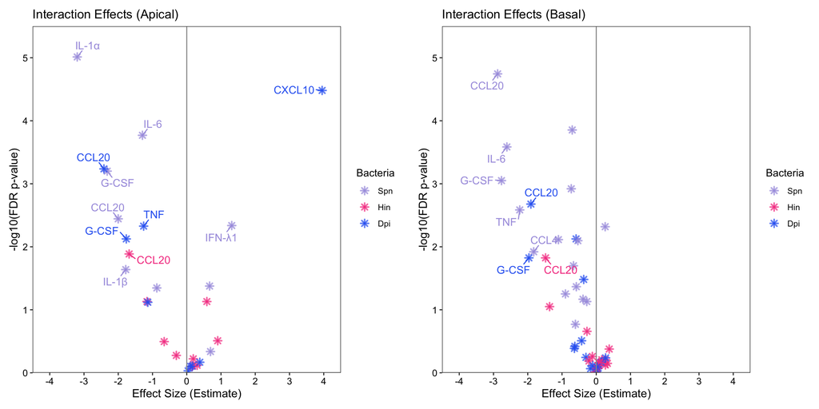

```r
# Function to create volcano plot by location
create_volcano_plot <- function(data, location_filter, xmin, xmax, ymin, ymax) {

  data_filtered <- data %>%
    filter(location == location_filter)

  ggplot(data_filtered, aes(x = estimate, y = -log10(as.numeric(adj.p.FDR)), color = contrast)) +
    geom_point(size = 2, alpha = 0.7, shape = 8, stroke = 1.2) +
    scale_color_manual(values = Bac.colors) +
    scale_x_continuous(expand = c(0, 0), limits = c(xmin, xmax), breaks = seq(floor(xmin), ceiling(xmax), by = 1)) +
    scale_y_continuous(expand = c(0, 0), limits = c(ymin, ymax)) +
    geom_hline(yintercept = -log10(1), color = "gray60") +
    geom_vline(xintercept = 0, color = "gray60") +
    geom_text_repel(data = data_filtered %>%
                      filter(as.numeric(adj.p.FDR) < 0.05) %>%
                      filter(estimate <= -1.25 | estimate >= 1.25),
                    aes(label = cytokine),
                    size = 4,
                    min.segment.length = 0,
                    box.padding = 0.5,
                    show.legend = FALSE) +
    labs(x = "Effect Size (Estimate)",
         y = "-log10(FDR p-value)",
         title = paste0("Interaction Effects (", location_filter, ")"),
         color = "Bacteria") +
    theme_bw() +
    theme(legend.position = "right",
          plot.margin = margin(t = 10, r = 10, b = 10, l = 10),
          panel.grid.major = element_blank(),
          panel.grid.minor = element_blank(),
          axis.title = element_text(size = 12),
          axis.text = element_text(size = 10, color = "black")
    )
}

# Create plots for apical and basal
plot_interac_apical <- create_volcano_plot(stats_contrasts_interaction, "Apical", xmin = -4.5, xmax = 4.5, ymin = 0, ymax = 5.5)
plot_interac_basal <- create_volcano_plot(stats_contrasts_interaction, "Basal", xmin = -4.5, xmax = 4.5, ymin = 0, ymax = 5.5)

ggarrange(plot_interac_apical, plot_interac_basal, ncol = 2)
```

```r
# Save interaction volcano plots
saveRDS(plot_interac_apical, file.path(outputs_folder, paste0(dataframeID, "_Interaction_Volcano_Apical_t4.rds")))
saveRDS(plot_interac_basal, file.path(outputs_folder, paste0(dataframeID, "_Interaction_Volcano_Basal_t4.rds")))
```

Example interpretation of the interaction effect calculation for Dpi CXCL10_Apical:

These are the mean predicted concentration values (pg/mL) for each condition:

```r
NB.NV <- 313.028488
Dpi.NV <- 3.850455
NB.RSV <- 5493.162761
Dpi.RSV <- 3519.681558
```

The log fold-changes for virus effect within each bacteria treatment are:

```r
logFC_NB <- log(NB.RSV / NB.NV)
logFC_NB
```

```
[1] 2.864965
```

```r
logFC_Dpi <- log(Dpi.RSV / Dpi.NV)
logFC_Dpi
```

```
[1] 6.817934
```

This means that when there is no bacteria RSV increases CXCL10_Apical production by a log fold-change of 2.8649653, while for Dpi, RSV increases CXCL10_Apical by a log fold-change of 6.8179345. The interaction effect visualized on the plots (Dpi vs. NB) is then calculated as the difference in log fold-changes, that in this case is equal to:

```r
logFC_interaction <- logFC_Dpi - logFC_NB
logFC_interaction
```

```
[1] 3.952969
```

## RSVbac 0 DPVI

```r
# Filter data for 4 DPVI timepoint
Cytokines_data_t0 <- Cytokines_data %>%
  filter(time_inf == "0")

# Create subfolder for output files
outputs_folder <- file.path(FOLDER_PATH, "outputs/Cytokines/0_DPVI")
if (!file.exists(outputs_folder)) {
  dir.create(outputs_folder, recursive = TRUE)
}

# Colors
Bac.Vir_colors <- c("#CC9564", "#a89de0", "#f54590", "#2e67f2")
Bac.Vir_fill <- c("white", "white", "white", "white")
```

### LOD and Heatmap of log2FC

This section performs quality control by calculating log2 fold changes (log2FC) relative to control samples (NB.NV), evaluating the proportion of samples above the detection limit for each cytokine-location combination, and assessing the dynamic range of responses. Cytokine-location groups with less than 25% detection across all samples are flagged as rejected and excluded from subsequent statistical analyses. Results are visualized through bar plots showing detection rates and dynamic ranges, a scatter plot examining the relationship between detection and range, and a heatmap displaying average log2FC values for each cytokine-location group. Samples highlighted in grey in the heatmap correspond to rejected cytokine-location groups (less than 25% of samples above detection limit).

```r
# NB.NV considered as control samples for the log2FC calculation
LD_data <- Cytokines_data_t0 %>%
  mutate(sample_type = if_else(bacteria == "NB" & virus == "NV", "control", "experimental"))
log2FC_results <- log2FC_analysis(LD_data)
```

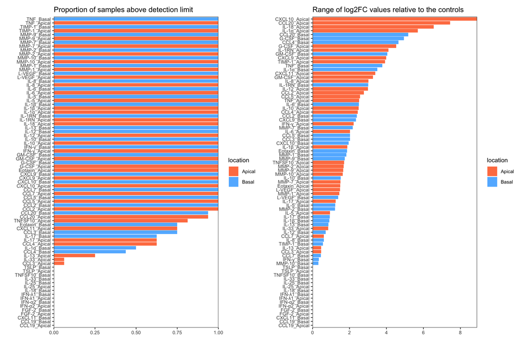

```r
log2FC_results$p_LD + log2FC_results$p_range
```

```r
ggplotly(log2FC_results$p_correlation_FC)
```

[interactive chart not shown]

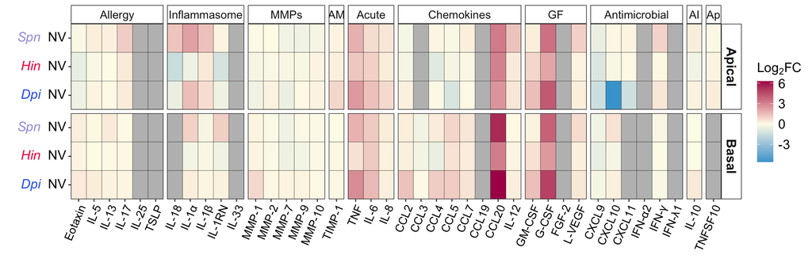

```r
log2FC_results$heatmap
```

```r
# Save log2FC_results
saveRDS(log2FC_results, file = file.path(outputs_folder, paste0(dataframeID, "_log2FC_results_t0.rds")))

# Merging the rejection info with the original data
Cytokines_data_t0 <- left_join(Cytokines_data_t0, log2FC_results$select_summary, by = join_by(Cyto, location))
saveRDS(Cytokines_data_t0, file = file.path(dataframes_folder, paste0(dataframeID, "_Cytokine_values_t0.rds")))

# Filtering out rejected groupings
Cytokines_data_t0 <- Cytokines_data_t0 %>%
  filter(group_rejected == FALSE)
```

### Stats and Individual Plots (pg/mL)

#### Handle missing values

This section summarizes the missing values in the dataset by bacteria-virus and cell line groups. It then filters out any rows with missing concentration values to prepare for statistical analysis.

```r
# Summary of missing values
Summary <- Cytokines_data_t0 %>%
  group_by(location, bacteria, virus, line) %>%
  summarise(
    missing = sum(is.na(concentration)),
    total = n()
  ) %>%
  mutate(percent_missing = round(missing / total * 100, 2))
kable(Summary)
```

| location | bacteria | virus | line | missing | total | percent_missing |
| --- | --- | --- | --- | --- | --- | --- |
| Apical | NB | NV | HNO9007 | 0 | 64 | 0 |
| Apical | NB | NV | HNO9009 | 0 | 64 | 0 |
| Apical | Spn | NV | HNO9007 | 0 | 64 | 0 |
| Apical | Spn | NV | HNO9009 | 0 | 64 | 0 |
| Apical | Hin | NV | HNO9007 | 0 | 64 | 0 |
| Apical | Hin | NV | HNO9009 | 0 | 64 | 0 |
| Apical | Dpi | NV | HNO9007 | 0 | 64 | 0 |
| Apical | Dpi | NV | HNO9009 | 0 | 64 | 0 |
| Basal | NB | NV | HNO9007 | 0 | 60 | 0 |
| Basal | NB | NV | HNO9009 | 0 | 60 | 0 |
| Basal | Spn | NV | HNO9007 | 0 | 60 | 0 |
| Basal | Spn | NV | HNO9009 | 0 | 60 | 0 |
| Basal | Hin | NV | HNO9007 | 0 | 60 | 0 |
| Basal | Hin | NV | HNO9009 | 0 | 60 | 0 |
| Basal | Dpi | NV | HNO9007 | 0 | 60 | 0 |
| Basal | Dpi | NV | HNO9009 | 0 | 60 | 0 |

```r
# Filter NA in concentration
Stats_values <- Cytokines_data_t0 %>%
  filter(!is.na(concentration)) %>%
  arrange(desc(range))
```

#### Statistical Analysis

This section performs univariate statistical analysis for each cytokine-location group separately using linear mixed-effects models. For each group, cytokine concentrations (log-transformed) are modeled as a function of bacteria treatment, with random effects for cell line and the cell line * date interaction to account for the nested repeated measures design. If the model is singular (typically due to zero variance for the line:date random effect), it is refitted with only date as a random effect. Model predictions and 95% confidence intervals are back-transformed to the original scale (pg/mL) for visualization. Pairwise contrasts are computed for simple effects of bacteria (comparing bacteria treatments within the non-virus level)

```r
stats_function <- function(values_data, each_group) {

  # Subset the data
  data_subset <- values_data %>%
    filter(group_label == each_group)

  # Set NB as reference level for bacteria
  data_subset$bacteria <- relevel(factor(data_subset$bacteria), ref = "NB")

  # First run linear mixed-effects model with random effects
  model <- lmer(log(concentration) ~ bacteria
                + (1|line) + (1|line:date),
                data = data_subset)

  # Extract random effects data and convert to dataframe
  singular = isSingular(model)
  random_effects_df <- as.data.frame(VarCorr(model)) %>%
    mutate(proportion = round(100 * (vcov / sum(vcov)), 2)) %>%
    mutate(singular = singular) %>%
    mutate(group_label = each_group)

  # If model is singular, rerun linear mixed-effects model with only date as random effect
  if (singular) {
    model <- lmer(log(concentration) ~ bacteria
                  + (1|date),
                  data = data_subset)
  }

  # Run ANOVA and extract pvalues
  anova <- anova(model)
  bacteria_pvalue <- anova$`Pr(>F)`[1]

  # Extract fixed effects coefficients and convert to dataframe
  fixed_effects_df <- as.data.frame(summary(model)$coefficients) %>%
    rownames_to_column(var = "term") %>%
    mutate(group_label = each_group)

  # Generate all individual contrasts without pvalue adjustment
  emmeans_model <- emmeans(model, ~ bacteria)
  emmeans_bacteria <- pairs(emmeans_model, simple = "bacteria", adjust = "none")

  # Extract bacteria contrasts from emmeans_model and format the dataframe
  contrasts_bacteria_df <- as.data.frame(summary(emmeans_bacteria)) %>%
    mutate(contrast = str_replace_all(contrast, "\\s+", "")) %>%
    mutate(group_label = each_group,
           anova_contrast = bacteria_pvalue) %>%
    separate(contrast, into = c("bacteria1", "bacteria2"), sep = "-") %>%
    mutate(condition1 = paste(bacteria1, "NV", sep = "."),
           condition2 = paste(bacteria2, "NV", sep = "."),
           contrast = paste(condition1, condition2, sep = " - ")) %>%
    dplyr::select(-c(bacteria1, bacteria2)) %>%
    relocate(contrast)

  contrasts_bacteria_df$group1 <- values_data$Bac.Vir_label_symbols[match(contrasts_bacteria_df$condition1, values_data$Bac.Vir)]
  contrasts_bacteria_df$group2 <- values_data$Bac.Vir_label_symbols[match(contrasts_bacteria_df$condition2, values_data$Bac.Vir)]

  # Combine contrasts dataframes #Only bacteria contrasts here but we keep the structure from other analyses
  contrasts_df <- rbind(contrasts_bacteria_df)

  # Adds predictions based on fixed effects, averaged over random effects. It gives a population estimate
  data_subset <- cbind(data_subset, predval = predict(model, re.form = NA, se.fit = TRUE))

  # Backtransform the predicted values and CIs
  transf_preds_df <- data_subset %>% group_by(bacteria, virus, group_label) %>%
    summarise(mean.predval.fit = mean(predval.fit),
              mean.predval.se.fit = mean(predval.se.fit),
              mean.concentration = mean(concentration),
              .groups = 'drop') %>%
    mutate(pconcentr = exp(mean.predval.fit),
           pconcentr_min = exp(mean.predval.fit - 2*mean.predval.se.fit),
           pconcentr_max = exp(mean.predval.fit + 2*mean.predval.se.fit)) %>%
    mutate(condition = interaction(bacteria, virus, sep = "."))

  transf_preds_df$Bac.Vir_label_symbols <- values_data$Bac.Vir_label_symbols[match(transf_preds_df$condition, values_data$Bac.Vir)]

  return(list(anova = anova,
              random_effects = random_effects_df,
              fixed_effects = fixed_effects_df,
              contrasts = contrasts_df,
              transf_preds = transf_preds_df))
}
```

```r
#Example use for a specific Cytokine-location group
each_group = "CXCL10_Apical"
stats_function(Stats_values, each_group)
```

P-values are adjusted for multiple comparisons across all contrasts within significant ANOVA effects using the false discovery rate (FDR) method.

```r
# Selection of conditions to perform contrast analysis based on anova
stats_contrasts_selection <- stats_contrasts %>%
  filter(anova_contrast < 0.05)

# Adjust across all Cyto-Location groups using FDR
stats_contrasts_selection <- stats_contrasts_selection %>%
  mutate(adj.p.FDR = p.adjust(p.value, method = "fdr")) %>%
  mutate(sign.FDR = ifelse(adj.p.FDR < 0.05, T, F)) %>%
  mutate(sign = case_when(
    adj.p.FDR < 0.05 ~ "*",
    TRUE ~ ""
  ))
stats_contrasts_selection$adj.p.FDR = format(stats_contrasts_selection$adj.p.FDR, digits = 2, scientific = TRUE)

# Calculate fold-change values for each contrast and highlight data for plotting brackets
stats_contrasts_selection <- stats_contrasts_selection %>%
  ungroup() %>%
  left_join(dplyr::select(stats_transf_preds, condition, group_label, pconcentr), by = join_by(group_label == group_label, condition1 == condition)) %>%
  left_join(dplyr::select(stats_transf_preds, condition, group_label, pconcentr), by = join_by(group_label == group_label, condition2 == condition), suffix = c(".1", ".2")) %>%
  mutate(FC = pconcentr.1 / pconcentr.2,
         log2FC = log2(FC),
         highlighted = case_when(
           sign.FDR == TRUE & log2FC >= 1 ~ "+",
           sign.FDR == TRUE & log2FC <= -1 ~ "-",
           TRUE ~ ""
         ))
```

#### Plotting Individual Cyto-location Groups

Results are visualized for each cytokine-location group with observed data points, model predictions with confidence intervals, and significance brackets for contrasts with FDR-adjusted p < 0.05.

```r
# Function to plot each individual Cyto-location group using pg/mL data
plot_function <- function(true_data, stats_data, contrasts, random, fixed, each_group) {

  # Subset data
  true_data <- true_data %>%
    filter(group_label == each_group)
  stats_data <- stats_data %>%
    filter(group_label == each_group)
  contrasts <- contrasts %>%
    filter(group_label == each_group)
  random <- random %>%
    filter(group_label == each_group)
  fixed <- fixed %>%
    filter(group_label == each_group)

  # Plot
  plot <- ggplot() +

    # True values in pg/mL
    geom_jitter(data = true_data,
                aes(x = Bac.Vir_label_symbols, y = concentration,
                    fill = Bac.Vir, color = Bac.Vir,
                    shape = line),
                width = 0.15, size = 3, stroke = 0.75, show.legend = TRUE) +

    scale_fill_manual(values = Bac.Vir_fill) +
    scale_color_manual(values = Bac.Vir_colors) +
    scale_shape_manual(values = c(21,24)) +

    # Predictions from the model transformed into pg/mL
    geom_point(data = stats_data, aes(x = Bac.Vir_label_symbols, y = pconcentr), shape = 3, size = 1) +
    geom_errorbar(data = stats_data, aes(x = Bac.Vir_label_symbols,
                                         y = pconcentr,
                                         ymin = pconcentr_min,
                                         ymax = pconcentr_max),
                  width = .15) +

    # General style
    scale_y_log10() +
    scale_x_discrete(expand = c(0,0.5)) +
    labs(title = each_group,
         x = "",
         y = "pg/mL",
         fill = "Condition", color = "Condition", shape = "HNO Line") +
    theme_bw() +
    theme(panel.grid = element_blank(),
          legend.text = element_markdown(),
          text = element_text(size = 12),
          plot.title = element_markdown(),
          axis.text.y = element_text(color = "black"),
          axis.text.x = element_markdown()) +
    guides(fill = guide_legend(override.aes = list(color = Bac.Vir_colors, shape = 22)))

  # Add significance asterisks for highlighted contrasts
  contrast_sign <- contrasts %>%
    filter(highlighted != "") %>%
    mutate(plot = "")

  if (nrow(contrast_sign) > 0) {
    plot <- plot +
      stat_pvalue_manual(contrast_sign, label = "plot", y.position = log10(max(true_data$concentration, na.rm = TRUE)),
                         step.increase = 0.04, tip.length = 0.01, bracket.shorten = 0.2, vjust = 0.6, bracket.size = 0.5)
  }

  # Conditionally arrange plot and p-values table if contrasts is not NULL
  Tmin <- ttheme_minimal()
  if (!is.null(contrasts) && nrow(contrasts) > 0) {
    contrasts <- contrasts %>%
      ungroup() %>%
      dplyr::select(-estimate, -SE, -t.ratio, -group_label, -condition1, -condition2, -sign.FDR, -p.value, -group1, -group2)

    panel <- ggarrange(plot + theme(plot.margin = unit(c(0.25, 0.25, 0.25, 0.25), "in")),
                       tableGrob(random, theme = Tmin, rows = NULL),
                       tableGrob(fixed, theme = Tmin, rows = NULL),
                       tableGrob(contrasts, theme = Tmin, rows = NULL),
                       ncol = 1, heights = c(0.4, 0.08, 0.15, 0.2))
  } else {
    panel <- ggarrange(plot + theme(plot.margin = unit(c(0.25, 0.25, 0.25, 0.25), "in")),
                       tableGrob(random, theme = Tmin, rows = NULL),
                       tableGrob(fixed, theme = Tmin, rows = NULL),
                       NULL,
                       ncol = 1, heights = c(0.4, 0.08, 0.15, 0.2))
  }
  return(list(each_group, plot, panel))
}
```

```r
# Example use for a specific Cytokine-location group
each_group = "CXCL10_Apical"
plot_function(Stats_values, stats_transf_preds, stats_contrasts_selection, stats_random_effects, stats_fixed_effects, each_group)
```

```r
plots_list <- purrr::map(unique(Stats_values$group_label), ~plot_function(true_data = Stats_values, stats_data = stats_transf_preds, contrasts = stats_contrasts_selection, fixed = stats_fixed_effects, random = stats_random_effects, .x))
```

```r
##| eval: false
## Save outputs
write_xlsx(stats_fixed_effects, file.path(outputs_folder, paste0(dataframeID, "_stats_fixed_effects_t0.xlsx")))
write_xlsx(stats_random_effects, file.path(outputs_folder, paste0(dataframeID, "_stats_random_effects_t0.xlsx")))
write_xlsx(stats_contrasts_selection, file.path(outputs_folder, paste0(dataframeID, "_stats_contrasts_t0.xlsx")))
write_xlsx(stats_transf_preds, file.path(outputs_folder, paste0(dataframeID, "_stats_transf_preds_t0.xlsx")))
saveRDS(stats_contrasts_selection, file.path(outputs_folder, paste0(dataframeID, "_stats_contrasts_t0.rds")))
saveRDS(stats_random_effects, file.path(outputs_folder, paste0(dataframeID, "_stats_random_effects_t0.rds")))

# Create subfolder for individual files
plots_folder <- file.path(outputs_folder, "individual_plots")
if (!file.exists(plots_folder)) {
  dir.create(plots_folder, recursive = TRUE)
}

# Save all multiple plots/tables on individual pdfs
for (i in seq_along(plots_list)) {
  plotname <- plots_list[[i]][[1]]
  ggsave(filename = paste0(plots_folder, "/", dataframeID, "_Cyto_Boxplot_t0_", plotname, ".png"),
         plot = plots_list[[i]][[3]], width = 12, height = 12, dpi = 300)
}

# Save all plot figures as an R object
saveRDS(plots_list, file.path(outputs_folder, paste0(dataframeID, "_plots_list_t0.rds")))
```